# UNICEF HEALTH EXPENSE EFFICIENCY ANALYSIS

### DATA PREPARATION

**LOAD DATASET 1: Estimates of under-five Mortality Rate by UNICEF region**

*Data is collected from [UNICEF Data Warehouse](https://data.unicef.org/resources/data_explorer/unicef_f/?ag=UNICEF&df=GLOBAL_DATAFLOW&ver=1.0&dq=.CME_MRY0T4..&startPeriod=2009&endPeriod=2019).*

**LOAD DATASET 2: Expense for health per region**

Data is collected from reports:  
[Global annual results report 2019 goal area 1](https://www.unicef.org/media/73351/file/Global-annual-results-report-2019-goal-area-1.pdf), [Global annual results report 2018 goal area 1](https://www.unicef.org/media/54971/file/Global_Annual_Results_Report_2018_Goal_Area_1.pdf), [Annual Results Report 2017 Health](https://www.unicef.org/media/47736/file/Annual_Results_Report_2017_Health.pdf), [Annual Results Report 2016](https://www.unicef.org/media/49126/file/2016arr_health.pdf), [UNICEF Annual Results Report 2015](https://www.unicef.org/media/50046/file/UNICEF_Annual_Report_2015_ENG.pdf), [2014 Annual Results Report health](https://www.unicef.org/media/50731/file/2014_Annual_Results_Report_health.pdf).

**Notes about the data**

- 2015 health expense data is not available at the regional level.
- All the under-five Mortality Rates in the plots are using the median uncertainty bounds.
- Filter dataset 1 by year and uncertainty bounds;
- Map regions using [UNICEF REGIONAL CLASSIFICATIONS](https://data.unicef.org/regionalclassifications/).
- Transform dataset 1 format wide to long.
- Join two datasets, below shows the top 10 rows of the final dataset.

| Region | Year | Under_Five_Mortality_Rate | Health_Expense |
| --- | --- | --- | --- |
| West and Central Africa | 2014 | 108.59 | 445.8 |
| West and Central Africa | 2015 | 105.98 | NA |
| West and Central Africa | 2016 | 103.17 | 494.0 |
| West and Central Africa | 2017 | 100.42 | 437.0 |
| West and Central Africa | 2018 | 97.54 | 370.0 |
| West and Central Africa | 2019 | 94.72 | 346.0 |
| Eastern and Southern Africa | 2014 | 66.80 | 326.1 |
| Eastern and Southern Africa | 2015 | 64.15 | NA |
| Eastern and Southern Africa | 2016 | 61.60 | 378.0 |
| Eastern and Southern Africa | 2017 | 59.40 | 344.0 |

### DATA VISUALIZATION

**LEVEL ONE: WORLD ESTIMATES OF under-five Mortality Rate VS. UNICEF TOTAL HEALTH EXPENSE IN US MILLIONS PER YEAR**

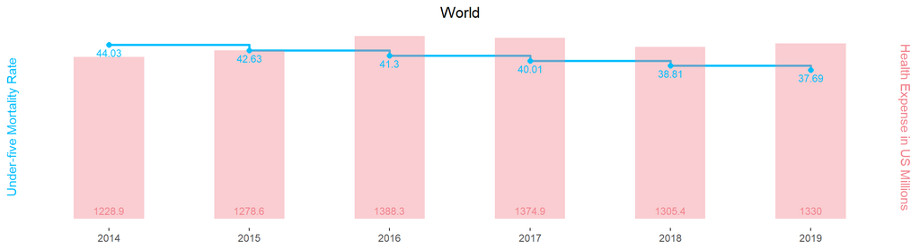

**LEVEL TWO: REGIONAL ESTIMATES OF under-five Mortality Rate VS. UNICEF TOTAL HEALTH EXPENSE IN US MILLIONS PER YEAR**

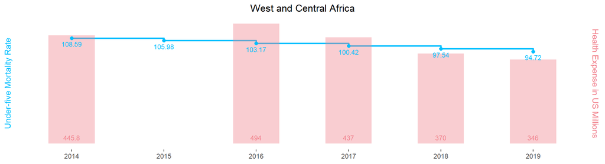

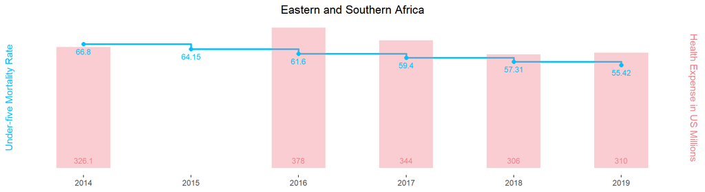

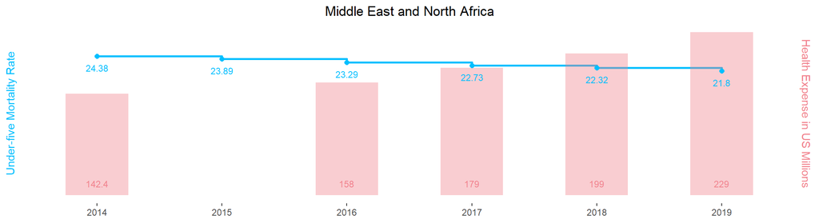

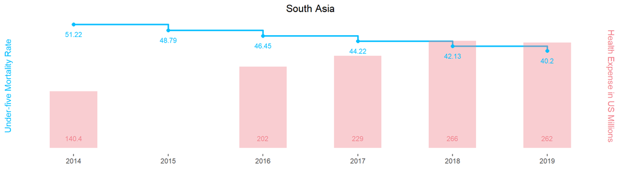

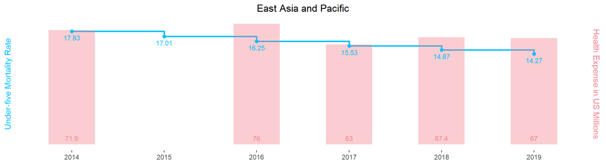

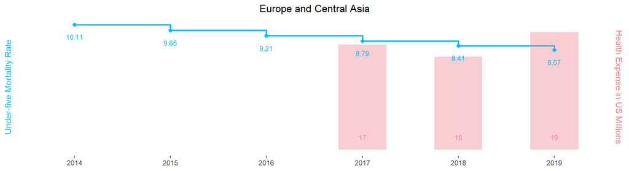

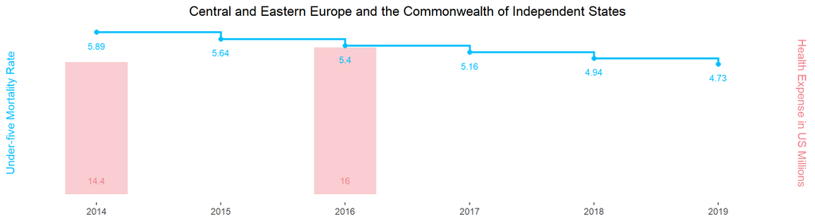

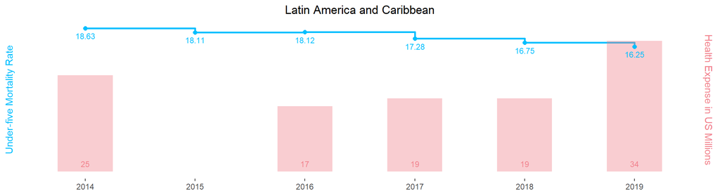

### DATA ANALYSIS

**Preliminary Findings**

Decreasing under-five Mortality Rate is an endeavor that requires **persistence**. Efforts and expenditure in previous years compound each year so that the net effect is a year over year decrease. As such, one would **not expect** a tight correlation between year over year expenditure and year over year under-five Mortality Rate. For example, a large increase or decrease in expenditure in a given year may not have an **immediately identifiable impact** on mortality rate in that year.

A more suitable analysis may be to use annual **moving averages** for the health expenditure and comparison to a **baseline year** for the under-five Mortality Rate. This would better capture the nature of a **cumulative effort**.

This being said, there are still some notable observations that can be made:

- In general, under-five Mortality Rate **decreases** year over year across all regions.
- The only region with an **increase in under-five Mortality Rate** is **Latin America and Caribbean**, which had a **32% decrease in health expense** in 2016 compared with 2014, the largest percentage decrease in health expense across all regions and all years.

**Future Work and Improvements**

- Deeper breakdown of health expenses at the **country level**.
- Analysis of **additional factors** that can affect under-five Mortality Rate (i.e.war, novel viruses, natural disasters, GDP, etc).
- Using an analysis that examines spending efficiency, it is possible to build a **forecasting** model in order to **monitor** the progress for each country or region and estimate the amount of spending needed in order to meet the 2030 SDG targets.